# MM Chapter 1

malcmac

2024-08-29

## R Markdown for MM Chapter 1

This is a streamlined document with essential data and figures for chapter 1 of MM’s dissertation. The goal of this chapter is to characterize the spatial structure of **water clarity and color** for 6 reservoirs across the longitudinal gradient of Texas during the extreme drought of Summer 2022.

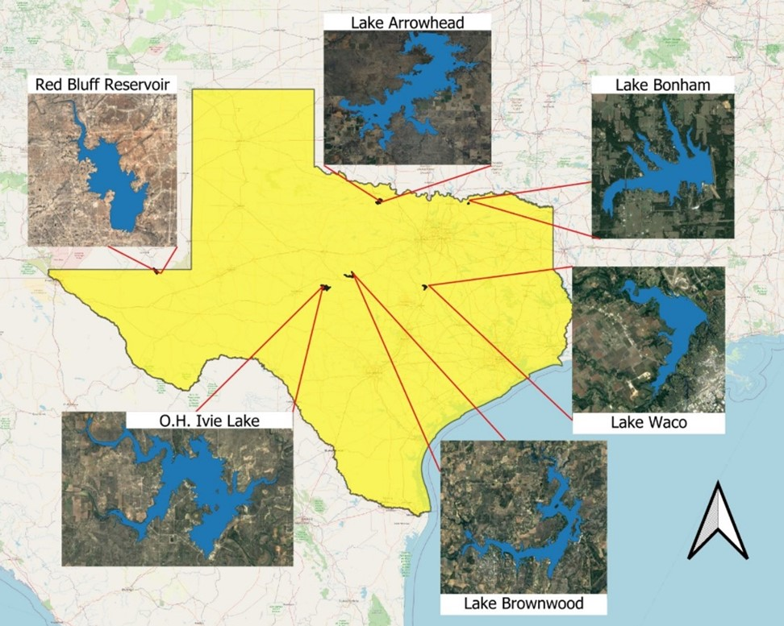

This research project involves 3 types of data which include (1) continuous measurements of turbidity taken along the boat path and Secchi disk depth predicted from those values (2) discrete lab measurements of water samples taken at 4-6 stations (n=31) within each reservoir, variables include Secchi, AFDM, TN, TP, and Turbidity (3) Sentinel-2 surface reflectance (SR) data from the flyover date on the sampling date for all surveys except Lake Brownwood which was the day after but within 24 hours.

The three levels of spatial analysis include (1) Along the boat path (2) Longitudinal transects from dam to reservoir arm (3) Whole system using all water pixels within a lake’s polygon. For spatial scale 1, the SR data used is from within 24 hours of survey. It is recommended to exclude the ~1500 points from Lake Waco that made it through filtering due to extensive sun glint on the survey data (7/23). For spatial scale 2, the SR data is for longitudinal transects from concurrent flyovers except for Lake Waco (7/25 instead of 7/23) and Lake Arrowhead (7/28 instead of 8/12), the same is true for the 3rd spatial scale of whole system. For the 3rd spatial scale, calculated DWL for the every water pixel using both the data product in GEE which was atmospherically corrected using Sen2Cor and also took the TOA data and corrected it to the Level-2 Water Product using ACOLITE.

## Visualizing Plots

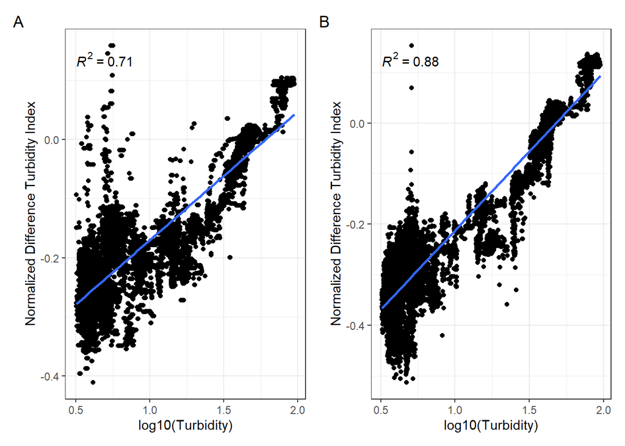

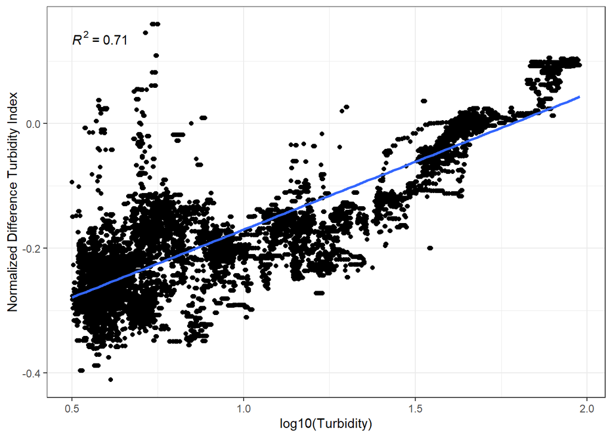

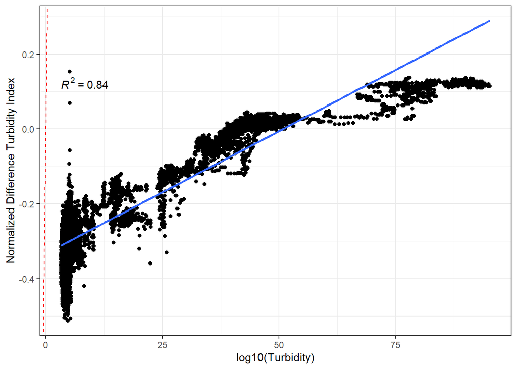

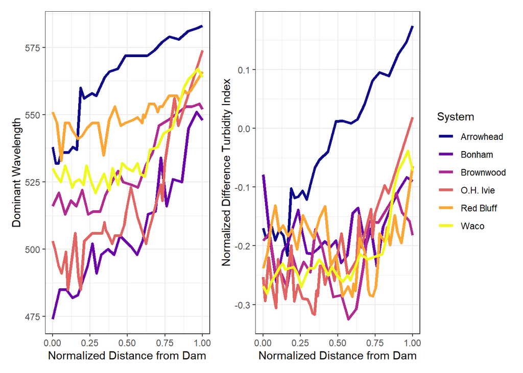

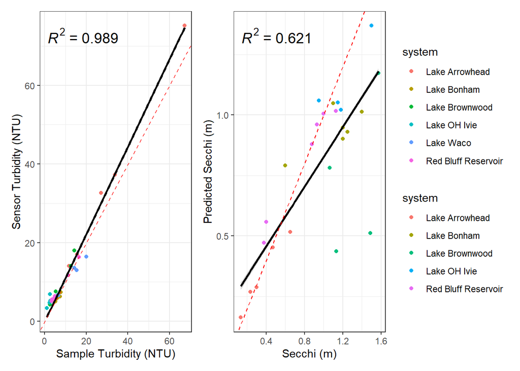

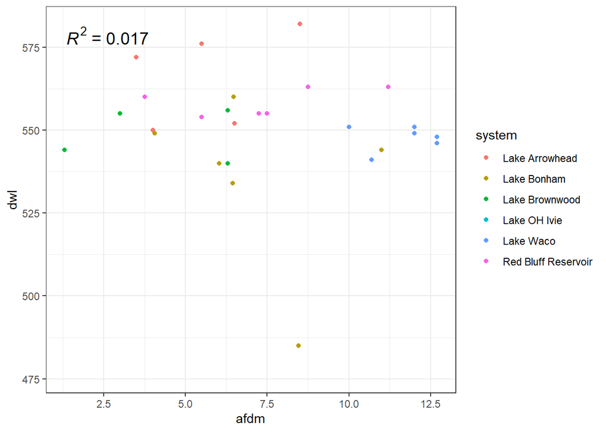

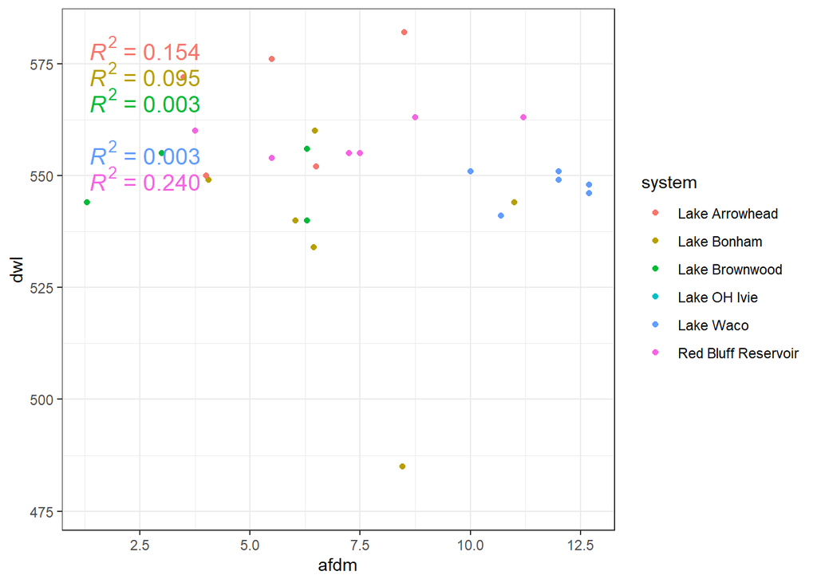